# MTH404 R Project

Jiqing Li

2023-04-20

## Data

```r
library(tidyverse)
```

```r
library(corrplot)
library(lubridate)
library(readr)
library(caTools)
library(GGally)
library(caret)
library(leaps)
library(dplyr)
library(ggplot2)
library(gridExtra)
```

## Load the data

By reading the provided train data in Excel, I have select some major columns from it as our traindata in R Project.

```r
traindata <- read.csv("~/train1.csv", header=TRUE)
testdata <- read.csv("~/test.csv", header=TRUE)
```

```r
str(traindata)
```

```
## 'data.frame':    1460 obs. of  22 variables:
##  $ Id          : int  1 2 3 4 5 6 7 8 9 10 ...
##  $ SalePrice   : int  208500 181500 223500 140000 250000 143000 307000 200000 129900 118000 ...
##  $ LotArea     : int  8450 9600 11250 9550 14260 14115 10084 10382 6120 7420 ...
##  $ Neighborhood: chr  "CollgCr" "Veenker" "CollgCr" "Crawfor" ...
##  $ OverallQual : int  7 6 7 7 8 5 8 7 7 5 ...
##  $ OverallCond : int  5 8 5 5 5 5 5 6 5 6 ...
##  $ YearBuilt   : int  2003 1976 2001 1915 2000 1993 2004 1973 1931 1939 ...
##  $ YearRemodAdd: int  2003 1976 2002 1970 2000 1995 2005 1973 1950 1950 ...
##  $ TotalBsmtSF : int  856 1262 920 756 1145 796 1686 1107 952 991 ...
##  $ X1stFlrSF   : int  856 1262 920 961 1145 796 1694 1107 1022 1077 ...
##  $ X2ndFlrSF   : int  854 0 866 756 1053 566 0 983 752 0 ...
##  $ GrLivArea   : int  1710 1262 1786 1717 2198 1362 1694 2090 1774 1077 ...
##  $ BsmtFullBath: int  1 0 1 1 1 1 1 1 0 1 ...
##  $ BsmtHalfBath: int  0 1 0 0 0 0 0 0 0 0 ...
##  $ FullBath    : int  2 2 2 1 2 1 2 2 2 1 ...
##  $ HalfBath    : int  1 0 1 0 1 1 0 1 0 0 ...
##  $ BedroomAbvGr: int  3 3 3 3 4 1 3 3 2 2 ...
##  $ KitchenAbvGr: int  1 1 1 1 1 1 1 1 2 2 ...
##  $ GarageCars  : int  2 2 2 3 3 2 2 2 2 1 ...
##  $ GarageArea  : int  548 460 608 642 836 480 636 484 468 205 ...
##  $ MoSold      : int  2 5 9 2 12 10 8 11 4 1 ...
##  $ YrSold      : int  2008 2007 2008 2006 2008 2009 2007 2009 2008 2008 ...
```

```r
head(traindata,10)
```

```
##    Id SalePrice LotArea Neighborhood OverallQual OverallCond YearBuilt
## 1   1    208500    8450      CollgCr           7           5      2003
## 2   2    181500    9600      Veenker           6           8      1976
## 3   3    223500   11250      CollgCr           7           5      2001
## 4   4    140000    9550      Crawfor           7           5      1915
## 5   5    250000   14260      NoRidge           8           5      2000
## 6   6    143000   14115      Mitchel           5           5      1993
## 7   7    307000   10084      Somerst           8           5      2004
## 8   8    200000   10382       NWAmes           7           6      1973
## 9   9    129900    6120      OldTown           7           5      1931
## 10 10    118000    7420      BrkSide           5           6      1939
##    YearRemodAdd TotalBsmtSF X1stFlrSF X2ndFlrSF GrLivArea BsmtFullBath
## 1          2003         856       856       854      1710            1
## 2          1976        1262      1262         0      1262            0
## 3          2002         920       920       866      1786            1
```

[output cut: 29 more lines]

## Clean and Modify Data

### STEP 1: Determine latest built date

#### Choose the latest year number in YearBuilt column and YearRemodAdd column as a new column, YearBuiltOrRe.

```r
traindata$YearBuiltOrRe <- pmax(traindata$YearBuilt, traindata$YearRemodAdd)

testdata$YearBuiltOrRe <- pmax(testdata$YearBuilt, testdata$YearRemodAdd)
```

### STEP 2: Determine total bathrooms

#### Find out the total Bathrooms, use 0.5 for half bath, 1 for full bath.

```r
traindata$TotalBath <- traindata$BsmtFullBath + (0.5 * traindata$BsmtHalfBath) +traindata$FullBath + (0.5 * traindata$HalfBath)

testdata$TotalBath <- testdata$BsmtFullBath + (0.5 * testdata$BsmtHalfBath) +testdata$FullBath + (0.5 * testdata$HalfBath)
```

### STEP 3: Rank neighborhoods with score

#### Find out the average sale price for house in each neighborhood. And replace neighborhood names with score from 1 to 10, rank by their average sale price.

```r
unique_items_in_Neighborhood_train <- unique(traindata$Neighborhood)
unique_items_in_Neighborhood_train # Find out all Neighborhood in traindata
```

```
##  [1] "CollgCr" "Veenker" "Crawfor" "NoRidge" "Mitchel" "Somerst" "NWAmes"
##  [8] "OldTown" "BrkSide" "Sawyer"  "NridgHt" "NAmes"   "SawyerW" "IDOTRR"
## [15] "MeadowV" "Edwards" "Timber"  "Gilbert" "StoneBr" "ClearCr" "NPkVill"
## [22] "Blmngtn" "BrDale"  "SWISU"   "Blueste"
```

```r
# Find out prices and mean price in each neighborhood provided
neighborhood_prices <- traindata %>%
  group_by(Neighborhood) %>%
  summarise(mean_price = mean(SalePrice),
            prices = list(SalePrice))

print.data.frame(neighborhood_prices[, c("Neighborhood", "mean_price")])
```

```
##    Neighborhood mean_price
## 1       Blmngtn  194870.88
## 2       Blueste  137500.00
## 3        BrDale  104493.75
## 4       BrkSide  124834.05
## 5       ClearCr  212565.43
## 6       CollgCr  197965.77
## 7       Crawfor  210624.73
## 8       Edwards  128219.70
## 9       Gilbert  192854.51
## 10       IDOTRR  100123.78
## 11      MeadowV   98576.47
## 12      Mitchel  156270.12
## 13        NAmes  145847.08
## 14      NPkVill  142694.44
## 15       NWAmes  189050.07
## 16      NoRidge  335295.32
## 17      NridgHt  316270.62
## 18      OldTown  128225.30
## 19        SWISU  142591.36
## 20       Sawyer  136793.14
## 21      SawyerW  186555.80
## 22      Somerst  225379.84
## 23      StoneBr  310499.00
## 24       Timber  242247.45
## 25      Veenker  238772.73
```

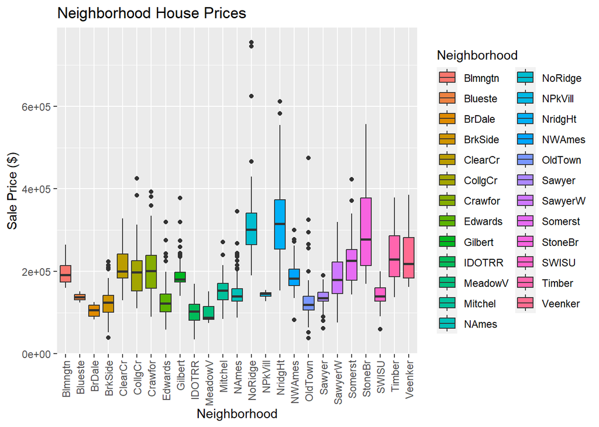

```r
# Graph Box plot to visually see how prices data locate in each neighborhood
ggplot(traindata, aes(x = Neighborhood, y = SalePrice, fill = Neighborhood)) +
  geom_boxplot() +
  ggtitle("Neighborhood House Prices") +
  ylab("Sale Price ($)") +
  xlab("Neighborhood") +
  scale_fill_discrete(name = "Neighborhood") +
  theme(axis.text.x = element_text(angle = 90, hjust = 1, vjust = 0.5))
```

```r
# Rank each neighborhood by SalePrice with score from 1 to 10
neighborhood_prices <- traindata %>%
  group_by(Neighborhood) %>%
  summarise(mean_price = mean(SalePrice)) %>%
  mutate(rank = rank(mean_price) / length(mean_price),
         NBscore = round(rank * 9) + 1)

print.data.frame(neighborhood_prices[, c("Neighborhood", "mean_price", "NBscore")])
```

```
##    Neighborhood mean_price NBscore
## 1       Blmngtn  194870.88       7
## 2       Blueste  137500.00       4
## 3        BrDale  104493.75       2
## 4       BrkSide  124834.05       2
## 5       ClearCr  212565.43       8
## 6       CollgCr  197965.77       7
## 7       Crawfor  210624.73       7
## 8       Edwards  128219.70       3
## 9       Gilbert  192854.51       6
## 10       IDOTRR  100123.78       2
## 11      MeadowV   98576.47       1
## 12      Mitchel  156270.12       5
## 13        NAmes  145847.08       5
## 14      NPkVill  142694.44       5
## 15       NWAmes  189050.07       6
## 16      NoRidge  335295.32      10
## 17      NridgHt  316270.62      10
## 18      OldTown  128225.30       3
## 19        SWISU  142591.36       4
## 20       Sawyer  136793.14       4
## 21      SawyerW  186555.80       6
## 22      Somerst  225379.84       8
## 23      StoneBr  310499.00       9
## 24       Timber  242247.45       9
## 25      Veenker  238772.73       9
```

```r
# Add Neighborhood Score in traindata
traindata <- traindata %>%
  left_join(neighborhood_prices[, c("Neighborhood", "NBscore")], by = "Neighborhood")
```

```r
unique_items_in_Neighborhood_test <- unique(testdata$Neighborhood)
unique_items_in_Neighborhood_test # Find out all Neighborhood in testdata
```

```
##  [1] "NAmes"   "Gilbert" "StoneBr" "BrDale"  "NPkVill" "NridgHt" "Blmngtn"
##  [8] "NoRidge" "Somerst" "SawyerW" "Sawyer"  "NWAmes"  "OldTown" "BrkSide"
## [15] "ClearCr" "SWISU"   "Edwards" "CollgCr" "Crawfor" "Blueste" "IDOTRR"
## [22] "Mitchel" "Timber"  "MeadowV" "Veenker"
```

```r
lookup_table <- unique(traindata[, c("Neighborhood", "NBscore")])

# Merge the testdata with the lookup table to get the NBscore for each neighborhood in testdata
testdata <- merge(testdata, lookup_table, by = "Neighborhood", all.x = TRUE)
```

### STEP 4: Check for the missing values

```r
NA_values=data.frame(no_of_na_values=colSums(is.na(traindata)))
head(NA_values,26)
```

```
##               no_of_na_values
## Id                          0
## SalePrice                   0
## LotArea                     0
## Neighborhood                0
## OverallQual                 0
## OverallCond                 0
## YearBuilt                   0
## YearRemodAdd                0
## TotalBsmtSF                 0
## X1stFlrSF                   0
## X2ndFlrSF                   0
## GrLivArea                   0
## BsmtFullBath                0
## BsmtHalfBath                0
## FullBath                    0
## HalfBath                    0
## BedroomAbvGr                0
## KitchenAbvGr                0
## GarageCars                  0
## GarageArea                  0
## MoSold                      0
## YrSold                      0
## YearBuiltOrRe               0
## TotalBath                   0
## NBscore                     0
```

### STEP 5: Clean all unnecessary columns

```r
traindata <- traindata %>%
  select(-c(Neighborhood, BsmtFullBath, BsmtHalfBath, FullBath, HalfBath, MoSold, YearBuilt, YearRemodAdd))



# Final look for traindata
head(traindata, 10)
```

```
##    Id SalePrice LotArea OverallQual OverallCond TotalBsmtSF X1stFlrSF X2ndFlrSF
## 1   1    208500    8450           7           5         856       856       854
## 2   2    181500    9600           6           8        1262      1262         0
## 3   3    223500   11250           7           5         920       920       866
## 4   4    140000    9550           7           5         756       961       756
## 5   5    250000   14260           8           5        1145      1145      1053
## 6   6    143000   14115           5           5         796       796       566
## 7   7    307000   10084           8           5        1686      1694         0
## 8   8    200000   10382           7           6        1107      1107       983
## 9   9    129900    6120           7           5         952      1022       752
## 10 10    118000    7420           5           6         991      1077         0
##    GrLivArea BedroomAbvGr KitchenAbvGr GarageCars GarageArea YrSold
## 1       1710            3            1          2        548   2008
## 2       1262            3            1          2        460   2007
## 3       1786            3            1          2        608   2008
```

[output cut: 18 more lines]

## Divide Data to 2 Subset

Subset 1 is named in train_data with a ratio of 0.8 traindata, subset 2 is named in teast_data with a ratio of 0.2 traindata.

```r
set.seed(700)   #  set seed to ensure you always have same random numbers generated
sample = sample.split(traindata,SplitRatio = 0.8)
train_data =subset(traindata,sample ==TRUE)
test_data=subset(traindata, sample==FALSE)
```

## Exploratory Data Analysis

### STEP 1: Correlation Plot

#### Determining the association between variables by their correlation.

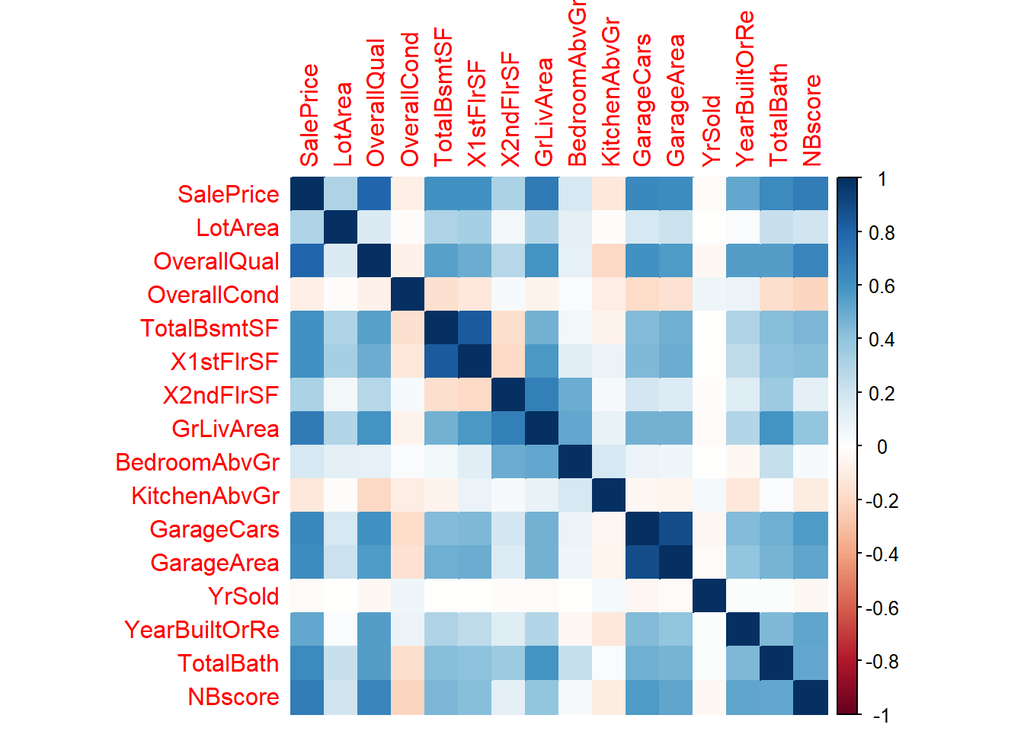

```r
cor_data=data.frame(train_data[,2:17])
correlation=cor(cor_data)
par(mfrow=c(1, 1))
corrplot(correlation,method="color")
```

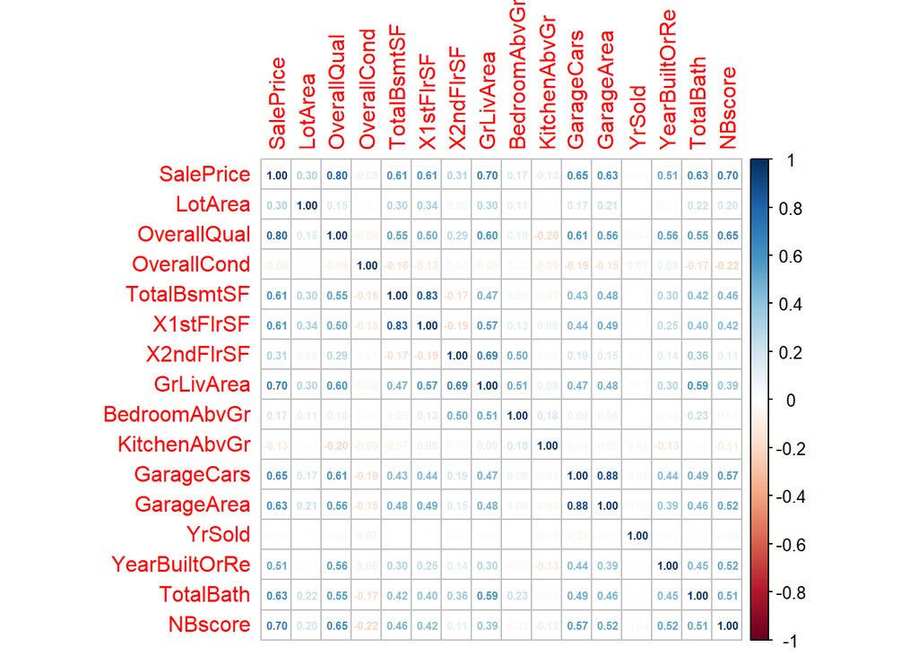

```r
corrplot(correlation,method="number", number.cex = 0.5)
```

According to our corrplot SalePrice is positively correlated with OverallQual, GrLivArea, GarageCars, YearBuiltOrRe, TotalBath, NBscore, LotArea, BedroomAbvGr, TotalBsmtSF, X1stFlrSF, X2ndFlrSF.

### STEP 2: Scatter plots and Boxplots

#### Draw to Scatter plots and Boxplots to determine the relationship between these variables.

From following scatter plots, we conclude that the relationship between OverallQual, GrLivArea, GarageCars, YearBuiltOrRe, TotalBath, NBscore and LotArea is linear

```r
p1=ggplot(data = train_data, aes(x = OverallQual, y = SalePrice)) +
  geom_jitter() +  geom_smooth(method = "lm", se = FALSE)+labs(title="Scatter plot of OverallQual and SalePrice", x="OverallQual",y="SalePrice") + theme(plot.title = element_text(size = 10))
p2=ggplot(data = train_data, aes(x = GrLivArea, y = SalePrice)) +
  geom_jitter() +  geom_smooth(method = "lm", se = FALSE)+labs(title="Scatter plot of GrLivArea and SalePrice", x="GrLivArea",y="SalePrice") + theme(plot.title = element_text(size = 10))
p3=ggplot(data = train_data, aes(x = GarageCars, y = SalePrice)) +
  geom_jitter() +  geom_smooth(method = "lm", se = FALSE)+labs(title="Scatter plot of GarageCars and SalePrice", x="GarageCars",y="SalePrice") + theme(plot.title = element_text(size = 10))
p4=ggplot(data = train_data, aes(x = YearBuiltOrRe, y = SalePrice)) +
  geom_jitter() +  geom_smooth(method = "lm", se = FALSE)+labs(title="Scatter plot of YearBuiltOrRe and SalePrice", x="YearBuiltOrRe",y="SalePrice") + theme(plot.title = element_text(size = 10))
p5=ggplot(data = train_data, aes(x = TotalBath, y = SalePrice)) +
  geom_jitter() +  geom_smooth(method = "lm", se = FALSE)+labs(title="Scatter plot of TotalBath and SalePrice", x="TotalBath",y="SalePrice") + theme(plot.title = element_text(size = 10))
p6=ggplot(data = train_data, aes(x = NBscore, y = SalePrice)) +
  geom_jitter() +  geom_smooth(method = "lm", se = FALSE)+labs(title="Scatter plot of NBscore and SalePrice", x="NBscore",y="SalePrice") + theme(plot.title = element_text(size = 10))
p7=ggplot(data = train_data, aes(x = LotArea, y = SalePrice)) +
  geom_jitter() +  geom_smooth(method = "lm", se = FALSE)+labs(title="Scatter plot of LotArea and SalePrice", x="LotArea",y="SalePrice") + theme(plot.title = element_text(size = 10))
p8=ggplot(data = train_data, aes(x = BedroomAbvGr, y = SalePrice)) +
  geom_jitter() +  geom_smooth(method = "lm", se = FALSE)+labs(title="Scatter plot of BedroomAbvGr and SalePrice", x="BedroomAbvGr",y="SalePrice") + theme(plot.title = element_text(size = 10))
p9=ggplot(data = train_data, aes(x = TotalBsmtSF, y = SalePrice)) +
  geom_jitter() +  geom_smooth(method = "lm", se = FALSE)+labs(title="Scatter plot of TotalBsmtSF and SalePrice", x="TotalBsmtSF",y="SalePrice") + theme(plot.title = element_text(size = 10))
p10=ggplot(data = train_data, aes(x = X1stFlrSF, y = SalePrice)) +
  geom_jitter() +  geom_smooth(method = "lm", se = FALSE)+labs(title="Scatter plot of X1stFlrSF and SalePrice", x="X1stFlrSF",y="SalePrice") + theme(plot.title = element_text(size = 10))
p11=ggplot(data = train_data, aes(x = X2ndFlrSF, y = SalePrice)) +
  geom_jitter() +  geom_smooth(method = "lm", se = FALSE)+labs(title="Scatter plot of X2ndFlrSF and SalePrice", x="X2ndFlrSF",y="SalePrice") + theme(plot.title = element_text(size = 10))
```

##### **Scatter Plots**

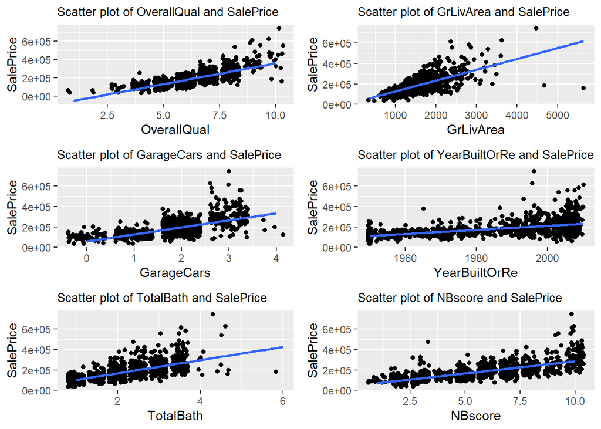

```r
grid.arrange(p1,p2,p3,p4,p5,p6,nrow=3)
```

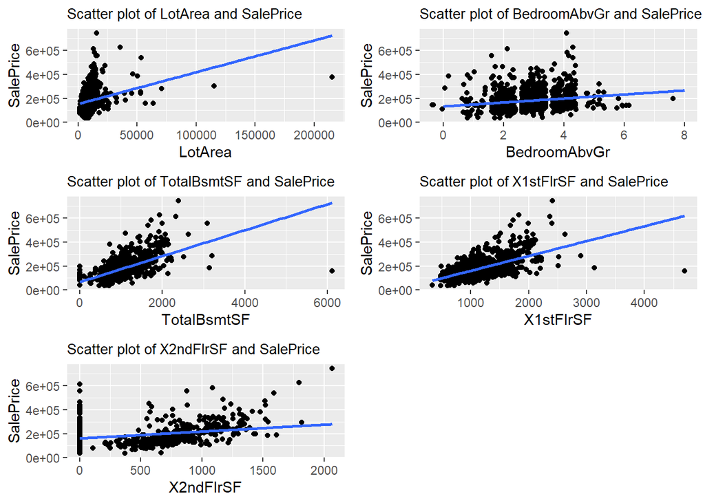

```r
grid.arrange(p7,p8,p9,p10,p11,nrow=3)
```

##### **Box Plots**

For the 4 categorical variables(OverallQual, GarageCars, TotalBath, and NBscore) we draw boxplots to understand the relationship.

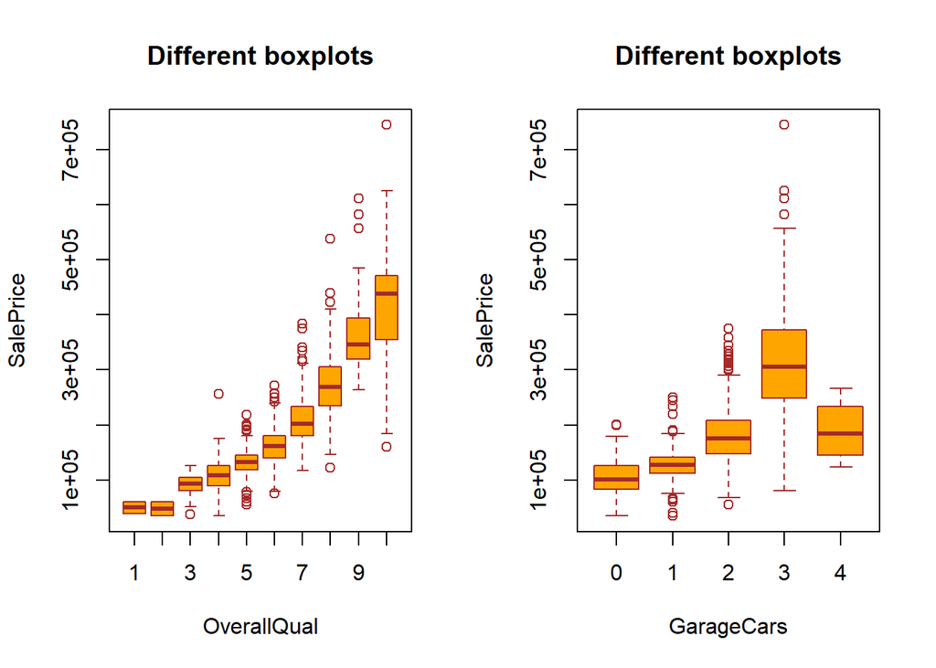

```r
par(mfrow=c(1, 2))
boxplot(SalePrice~OverallQual,data=train_data,main="Different boxplots", xlab="OverallQual",ylab="SalePrice",col="orange",border="brown")
boxplot(SalePrice~GarageCars,data=train_data,main="Different boxplots", xlab="GarageCars",ylab="SalePrice",col="orange",border="brown")
```

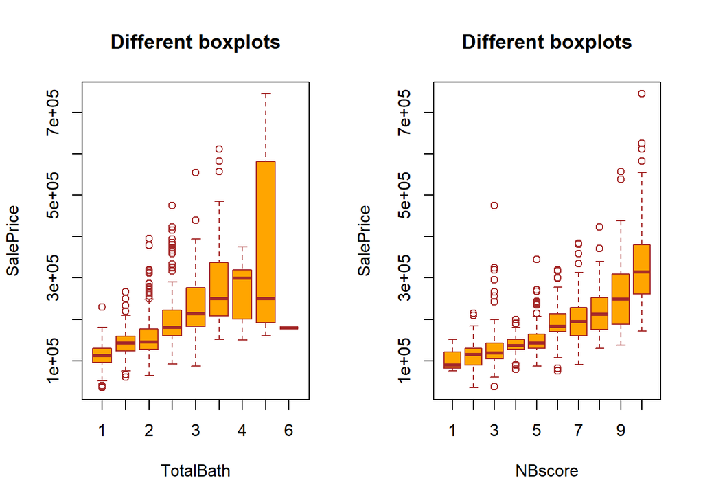

```r
boxplot(SalePrice~TotalBath,data=train_data,main="Different boxplots", xlab="TotalBath",ylab="SalePrice",col="orange",border="brown")
boxplot(SalePrice~NBscore,data=train_data,main="Different boxplots", xlab="NBscore",ylab="SalePrice",col="orange",border="brown")
```

There is a relationship between price and categorical variables, OverallQual, GarageCars, TotalBath, and NBscore.

### STEP 3: Performing ggpair plot.

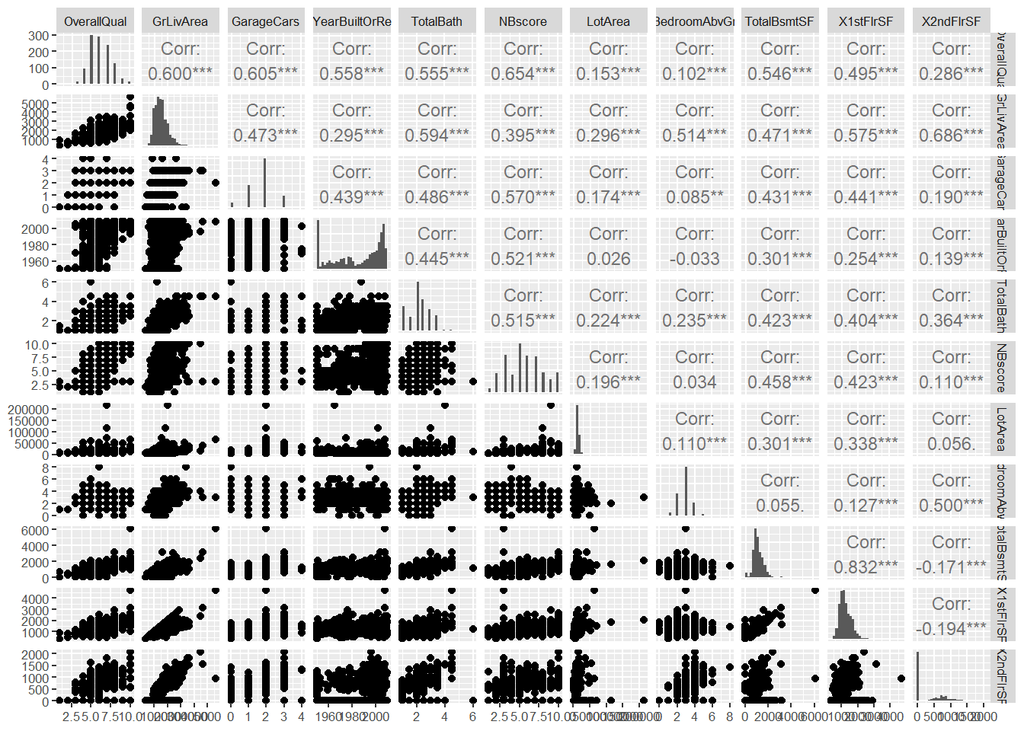

```r
ggpairs(train_data,
        columns= c("OverallQual","GrLivArea","GarageCars","YearBuiltOrRe","TotalBath","NBscore","LotArea","BedroomAbvGr","TotalBsmtSF","X1stFlrSF", "X2ndFlrSF"),
        diag = list(continuous = wrap("barDiag", cex = 0.5)),
        upper = list(continuous = wrap("cor", size = 3))) +
  theme_grey(base_size = 8)
```

### STEP 4: Determine outliers with boxplots

#### Check and analysis for outliers in the dependent variable(price) using a boxplot.

##### **a. Identify Outliers by drawing boxplot**

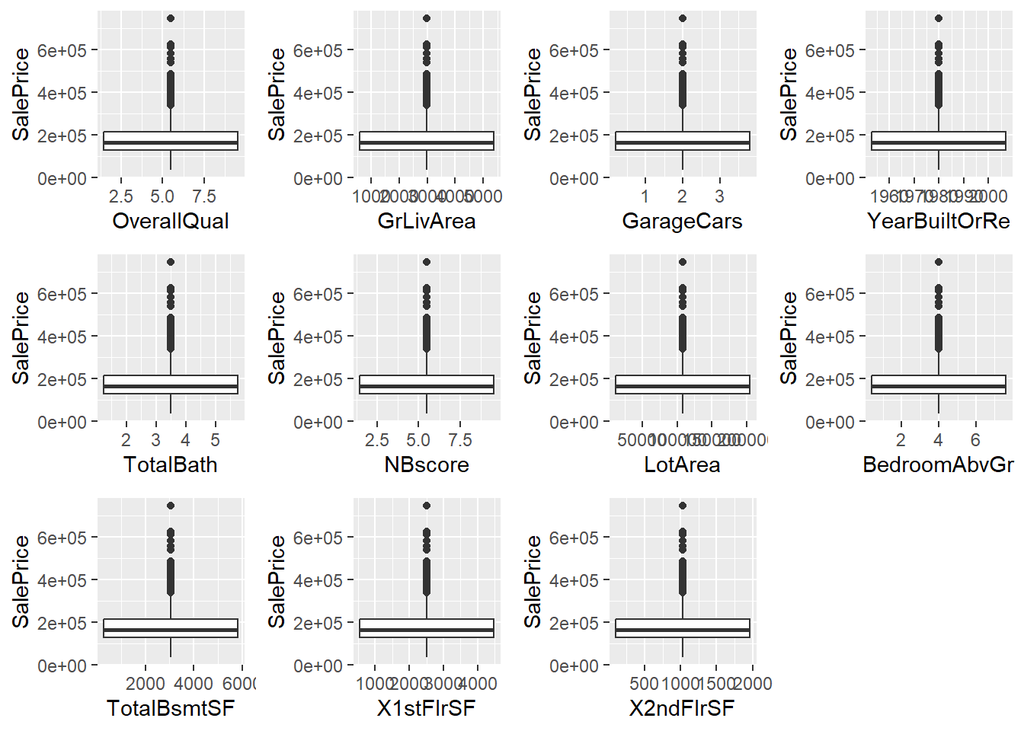

```r
b1 <- ggplot(data=train_data)+geom_boxplot(aes(x=OverallQual,y=SalePrice))
b2 <- ggplot(data=train_data)+geom_boxplot(aes(x=GrLivArea,y=SalePrice))
b3 <- ggplot(data=train_data)+geom_boxplot(aes(x=GarageCars,y=SalePrice))
b4 <- ggplot(data=train_data)+geom_boxplot(aes(x=YearBuiltOrRe,y=SalePrice))
b5 <- ggplot(data=train_data)+geom_boxplot(aes(x=TotalBath,y=SalePrice))
b6 <- ggplot(data=train_data)+geom_boxplot(aes(x=NBscore,y=SalePrice))
b7 <- ggplot(data=train_data)+geom_boxplot(aes(x=LotArea,y=SalePrice))
b8 <- ggplot(data=train_data)+geom_boxplot(aes(x=BedroomAbvGr,y=SalePrice))
b9 <- ggplot(data=train_data)+geom_boxplot(aes(x=TotalBsmtSF,y=SalePrice))
b10 <- ggplot(data=train_data)+geom_boxplot(aes(x=X1stFlrSF,y=SalePrice))
b11 <- ggplot(data=train_data)+geom_boxplot(aes(x=X2ndFlrSF,y=SalePrice))

grid.arrange(b1, b2, b3, b4, b5, b6, b7, b8, b9, b10, b11, nrow=3)
```

##### **b. Create new data set without all outliers named in train_data1**

```r
outliers=boxplot(train_data$SalePrice,plot=FALSE)$out
outliers_data=train_data[which(train_data$SalePrice %in% outliers),]
train_data1= train_data[-which(train_data$SalePrice %in% outliers),]
length(outliers)
```

```
## [1] 51
```

##### **c. Analysis datas with Outliers and without Outliers in scatter plot**

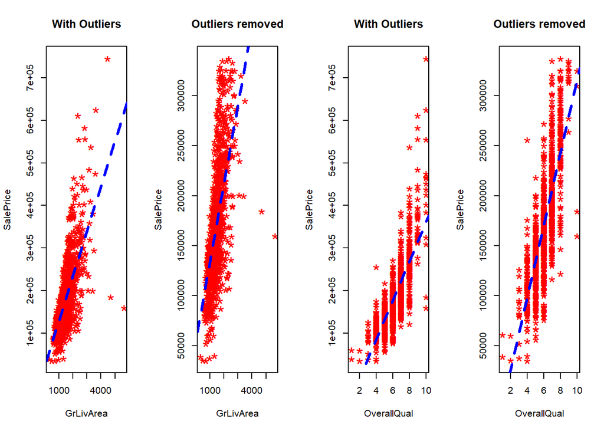

```r
par(mfrow=c(1, 4))

# OverallQual
plot(train_data$GrLivArea, train_data$SalePrice, main="With Outliers", xlab="GrLivArea", ylab="SalePrice", pch="*", col="red", cex=2)
abline(lm(SalePrice ~ GrLivArea, data=train_data), col="blue", lwd=3, lty=2)
plot(train_data1$GrLivArea, train_data1$SalePrice, main="Outliers removed", xlab="GrLivArea", ylab="SalePrice", pch="*", col="red", cex=2)
abline(lm(SalePrice ~GrLivArea, data=train_data1), col="blue", lwd=3, lty=2)

# GrLivArea
plot(train_data$OverallQual, train_data$SalePrice, main="With Outliers", xlab="OverallQual", ylab="SalePrice", pch="*", col="red", cex=2)
abline(lm(SalePrice ~ OverallQual, data=train_data), col="blue", lwd=3, lty=2)
plot(train_data1$OverallQual, train_data1$SalePrice, main="Outliers removed", xlab="OverallQual", ylab="SalePrice", pch="*", col="red", cex=2)
abline(lm(SalePrice ~OverallQual, data=train_data1), col="blue", lwd=3, lty=2)
```

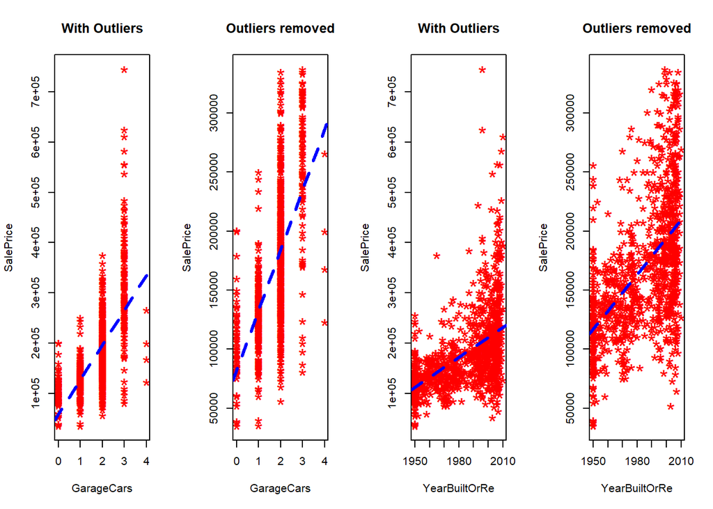

```r
# GarageCars
plot(train_data$GarageCars, train_data$SalePrice, main="With Outliers", xlab="GarageCars", ylab="SalePrice", pch="*", col="red", cex=2)
abline(lm(SalePrice ~ GarageCars, data=train_data), col="blue", lwd=3, lty=2)
plot(train_data1$GarageCars, train_data1$SalePrice, main="Outliers removed", xlab="GarageCars", ylab="SalePrice", pch="*", col="red", cex=2)
abline(lm(SalePrice ~GarageCars, data=train_data1), col="blue", lwd=3, lty=2)

# YearBuiltOrRe
plot(train_data$YearBuiltOrRe, train_data$SalePrice, main="With Outliers", xlab="YearBuiltOrRe", ylab="SalePrice", pch="*", col="red", cex=2)
abline(lm(SalePrice ~ YearBuiltOrRe, data=train_data), col="blue", lwd=3, lty=2)
plot(train_data1$YearBuiltOrRe, train_data1$SalePrice, main="Outliers removed", xlab="YearBuiltOrRe", ylab="SalePrice", pch="*", col="red", cex=2)
abline(lm(SalePrice ~ YearBuiltOrRe, data=train_data1), col="blue", lwd=3, lty=2)
```

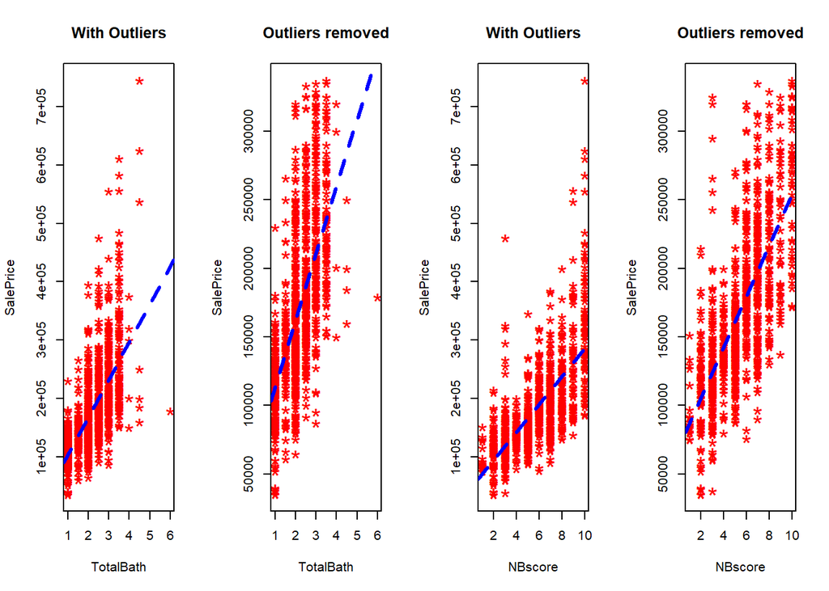

```r
# TotalBath
plot(train_data$TotalBath, train_data$SalePrice, main="With Outliers", xlab="TotalBath", ylab="SalePrice", pch="*", col="red", cex=2)
abline(lm(SalePrice ~ TotalBath, data=train_data), col="blue", lwd=3, lty=2)
plot(train_data1$TotalBath, train_data1$SalePrice, main="Outliers removed", xlab="TotalBath", ylab="SalePrice", pch="*", col="red", cex=2)
abline(lm(SalePrice ~ TotalBath, data=train_data1), col="blue", lwd=3, lty=2)

# NBscore
plot(train_data$NBscore, train_data$SalePrice, main="With Outliers", xlab="NBscore", ylab="SalePrice", pch="*", col="red", cex=2)
abline(lm(SalePrice ~ NBscore, data=train_data), col="blue", lwd=3, lty=2)
plot(train_data1$NBscore, train_data1$SalePrice, main="Outliers removed", xlab="NBscore", ylab="SalePrice", pch="*", col="red", cex=2)
abline(lm(SalePrice ~ NBscore, data=train_data1), col="blue", lwd=3, lty=2)
```

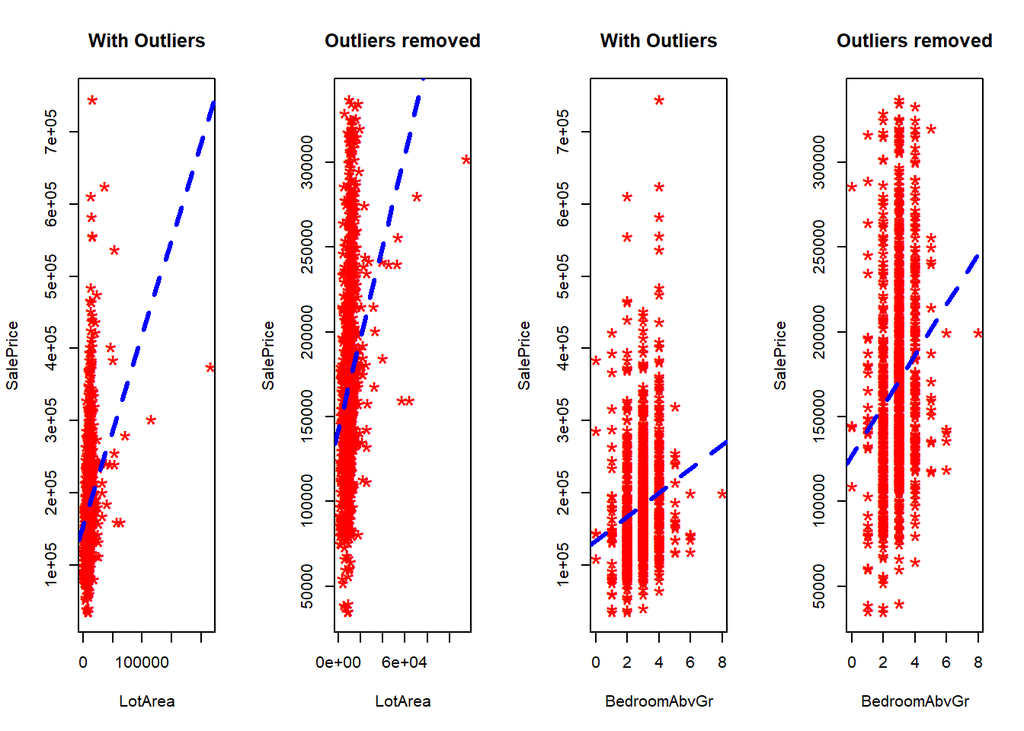

```r
# LotArea
plot(train_data$LotArea, train_data$SalePrice, main="With Outliers", xlab="LotArea", ylab="SalePrice", pch="*", col="red", cex=2)
abline(lm(SalePrice ~ LotArea, data=train_data), col="blue", lwd=3, lty=2)
plot(train_data1$LotArea, train_data1$SalePrice, main="Outliers removed", xlab="LotArea", ylab="SalePrice", pch="*", col="red", cex=2)
abline(lm(SalePrice ~ LotArea, data=train_data1), col="blue", lwd=3, lty=2)

# BedroomAbvGr
plot(train_data$BedroomAbvGr, train_data$SalePrice, main="With Outliers", xlab="BedroomAbvGr", ylab="SalePrice", pch="*", col="red", cex=2)
abline(lm(SalePrice ~ BedroomAbvGr, data=train_data), col="blue", lwd=3, lty=2)
plot(train_data1$BedroomAbvGr, train_data1$SalePrice, main="Outliers removed", xlab="BedroomAbvGr", ylab="SalePrice", pch="*", col="red", cex=2)
abline(lm(SalePrice ~ BedroomAbvGr, data=train_data1), col="blue", lwd=3, lty=2)
```

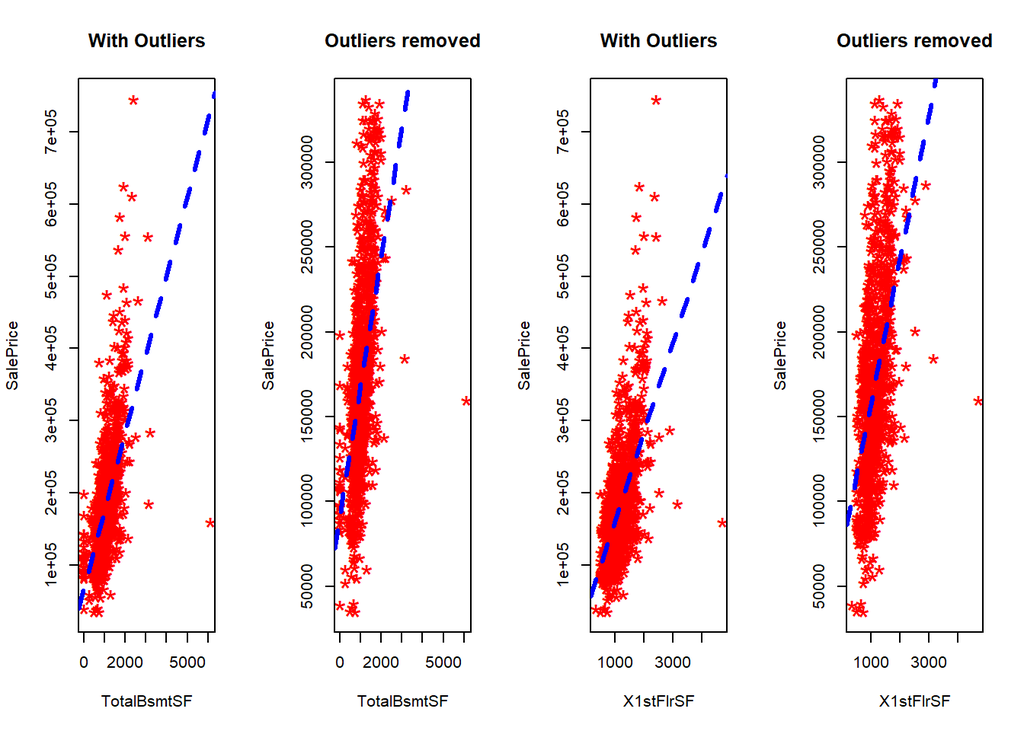

```r
# TotalBsmtSF
plot(train_data$TotalBsmtSF, train_data$SalePrice, main="With Outliers", xlab="TotalBsmtSF", ylab="SalePrice", pch="*", col="red", cex=2)
abline(lm(SalePrice ~ TotalBsmtSF, data=train_data), col="blue", lwd=3, lty=2)
plot(train_data1$TotalBsmtSF, train_data1$SalePrice, main="Outliers removed", xlab="TotalBsmtSF", ylab="SalePrice", pch="*", col="red", cex=2)
abline(lm(SalePrice ~ TotalBsmtSF, data=train_data1), col="blue", lwd=3, lty=2)

# X1stFlrSF
plot(train_data$X1stFlrSF, train_data$SalePrice, main="With Outliers", xlab="X1stFlrSF", ylab="SalePrice", pch="*", col="red", cex=2)
abline(lm(SalePrice ~ X1stFlrSF, data=train_data), col="blue", lwd=3, lty=2)
plot(train_data1$X1stFlrSF, train_data1$SalePrice, main="Outliers removed", xlab="X1stFlrSF", ylab="SalePrice", pch="*", col="red", cex=2)
abline(lm(SalePrice ~ X1stFlrSF, data=train_data1), col="blue", lwd=3, lty=2)
```

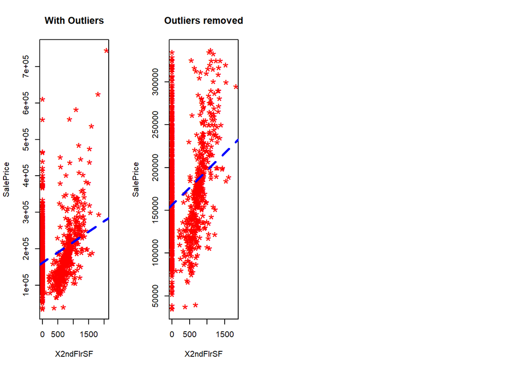

```r
# X2ndFlrSF
plot(train_data$X2ndFlrSF, train_data$SalePrice, main="With Outliers", xlab="X2ndFlrSF", ylab="SalePrice", pch="*", col="red", cex=2)
abline(lm(SalePrice ~ X2ndFlrSF, data=train_data), col="blue", lwd=3, lty=2)
plot(train_data1$X2ndFlrSF, train_data1$SalePrice, main="Outliers removed", xlab="X2ndFlrSF", ylab="SalePrice", pch="*", col="red", cex=2)
abline(lm(SalePrice ~ X2ndFlrSF, data=train_data1), col="blue", lwd=3, lty=2)
```

## Modeling

### STEP 1: Model on the all train data

SalePrice, OverallQual, GrLivArea, GarageCars, YearBuiltOrRe, TotalBath, NBscore, LotArea, BedroomAbvGr, TotalBsmtSF, X1stFlrSF, X2ndFlrSF were considered for the full model based on the corrplot.

#### Model 1: linear fit of all variables.

```r
model1=lm(data=train_data,SalePrice~OverallQual+GrLivArea+GarageCars+YearBuiltOrRe+TotalBath+NBscore+LotArea+BedroomAbvGr+TotalBsmtSF+X1stFlrSF+X2ndFlrSF)
summary(model1)
```

```
##
## Call:
## lm(formula = SalePrice ~ OverallQual + GrLivArea + GarageCars +
##     YearBuiltOrRe + TotalBath + NBscore + LotArea + BedroomAbvGr +
##     TotalBsmtSF + X1stFlrSF + X2ndFlrSF, data = train_data)
##
## Residuals:
##     Min      1Q  Median      3Q     Max
## -399547  -18030   -1831   15041  278310
##
## Coefficients:
##                 Estimate Std. Error t value Pr(>|t|)
## (Intercept)   -3.603e+05  1.303e+05  -2.766 0.005766 **
## OverallQual    1.684e+04  1.329e+03  12.675  < 2e-16 ***
## GrLivArea      2.948e+01  2.346e+01   1.256 0.209226
## GarageCars     1.099e+04  1.946e+03   5.645 2.10e-08 ***
## YearBuiltOrRe  1.416e+02  6.696e+01   2.114 0.034702 *
## TotalBath      6.846e+03  1.918e+03   3.570 0.000372 ***
## NBscore        7.347e+03  6.723e+02  10.927  < 2e-16 ***
## LotArea        5.442e-01  1.290e-01   4.219 2.66e-05 ***
## BedroomAbvGr  -5.360e+03  1.630e+03  -3.288 0.001041 **
## TotalBsmtSF    1.366e+01  4.603e+00   2.967 0.003074 **
## X1stFlrSF      2.340e+01  2.409e+01   0.972 0.331449
## X2ndFlrSF      1.482e+01  2.388e+01   0.620 0.535155
## ---
## Signif. codes:  0 '***' 0.001 '**' 0.01 '*' 0.05 '.' 0.1 ' ' 1
##
## Residual standard error: 35850 on 1104 degrees of freedom
## Multiple R-squared:  0.8007, Adjusted R-squared:  0.7987
## F-statistic: 403.1 on 11 and 1104 DF,  p-value: < 2.2e-16
```

#### Model 2: linear fit of part variables.

```r
model2=lm(data=train_data,SalePrice~OverallQual+GarageCars+YearBuiltOrRe+TotalBath+NBscore+LotArea+BedroomAbvGr+TotalBsmtSF)
summary(model2)
```

```
##
## Call:
## lm(formula = SalePrice ~ OverallQual + GarageCars + YearBuiltOrRe +
##     TotalBath + NBscore + LotArea + BedroomAbvGr + TotalBsmtSF,
##     data = train_data)
##
## Residuals:
##     Min      1Q  Median      3Q     Max
## -309814  -19738   -3462   15290  348969
##
## Coefficients:
##                 Estimate Std. Error t value Pr(>|t|)
## (Intercept)   -3.007e+05  1.401e+05  -2.146   0.0321 *
## OverallQual    2.295e+04  1.327e+03  17.300  < 2e-16 ***
## GarageCars     1.463e+04  2.065e+03   7.087 2.44e-12 ***
## YearBuiltOrRe  9.807e+01  7.202e+01   1.362   0.1735
## TotalBath      1.403e+04  1.961e+03   7.157 1.50e-12 ***
## NBscore        6.398e+03  7.186e+02   8.904  < 2e-16 ***
## LotArea        8.498e-01  1.365e-01   6.224 6.87e-10 ***
## BedroomAbvGr   6.120e+03  1.471e+03   4.161 3.42e-05 ***
## TotalBsmtSF    2.615e+01  3.256e+00   8.033 2.42e-15 ***
## ---
## Signif. codes:  0 '***' 0.001 '**' 0.01 '*' 0.05 '.' 0.1 ' ' 1
##
## Residual standard error: 38630 on 1107 degrees of freedom
## Multiple R-squared:  0.7678, Adjusted R-squared:  0.7662
## F-statistic: 457.7 on 8 and 1107 DF,  p-value: < 2.2e-16
```

By drop this variables a lower Adjusted R-Suared value, **0.7662** appeared. Thus we shouldn’t drop these varibles in our regression model.

### STEP 2: Model outliers from variables

#### Model the entire training data and decide on the retention of outliers in different variables.

#### Model 1: with all outliers

```r
# with all outliers
model1=lm(data=train_data,SalePrice~OverallQual+GrLivArea+GarageCars+YearBuiltOrRe+TotalBath+NBscore+LotArea+BedroomAbvGr+TotalBsmtSF+X1stFlrSF+X2ndFlrSF)
summary(model1)
```

```
##
## Call:
## lm(formula = SalePrice ~ OverallQual + GrLivArea + GarageCars +
##     YearBuiltOrRe + TotalBath + NBscore + LotArea + BedroomAbvGr +
##     TotalBsmtSF + X1stFlrSF + X2ndFlrSF, data = train_data)
##
## Residuals:
##     Min      1Q  Median      3Q     Max
## -399547  -18030   -1831   15041  278310
##
## Coefficients:
##                 Estimate Std. Error t value Pr(>|t|)
## (Intercept)   -3.603e+05  1.303e+05  -2.766 0.005766 **
## OverallQual    1.684e+04  1.329e+03  12.675  < 2e-16 ***
## GrLivArea      2.948e+01  2.346e+01   1.256 0.209226
## GarageCars     1.099e+04  1.946e+03   5.645 2.10e-08 ***
## YearBuiltOrRe  1.416e+02  6.696e+01   2.114 0.034702 *
## TotalBath      6.846e+03  1.918e+03   3.570 0.000372 ***
## NBscore        7.347e+03  6.723e+02  10.927  < 2e-16 ***
## LotArea        5.442e-01  1.290e-01   4.219 2.66e-05 ***
## BedroomAbvGr  -5.360e+03  1.630e+03  -3.288 0.001041 **
## TotalBsmtSF    1.366e+01  4.603e+00   2.967 0.003074 **
## X1stFlrSF      2.340e+01  2.409e+01   0.972 0.331449
## X2ndFlrSF      1.482e+01  2.388e+01   0.620 0.535155
## ---
## Signif. codes:  0 '***' 0.001 '**' 0.01 '*' 0.05 '.' 0.1 ' ' 1
##
## Residual standard error: 35850 on 1104 degrees of freedom
## Multiple R-squared:  0.8007, Adjusted R-squared:  0.7987
## F-statistic: 403.1 on 11 and 1104 DF,  p-value: < 2.2e-16
```

#### Model 3: without all outliers

```r
# without all outliers


model3=lm(data=train_data1,SalePrice~OverallQual+GrLivArea+GarageCars+YearBuiltOrRe+TotalBath+NBscore+LotArea+BedroomAbvGr+TotalBsmtSF+X1stFlrSF+X2ndFlrSF)
summary(model3)
```

```
##
## Call:
## lm(formula = SalePrice ~ OverallQual + GrLivArea + GarageCars +
##     YearBuiltOrRe + TotalBath + NBscore + LotArea + BedroomAbvGr +
##     TotalBsmtSF + X1stFlrSF + X2ndFlrSF, data = train_data1)
##
## Residuals:
##     Min      1Q  Median      3Q     Max
## -278891  -13628    -516   13462   99663
##
## Coefficients:
##                 Estimate Std. Error t value Pr(>|t|)
## (Intercept)   -5.080e+05  9.284e+04  -5.472 5.57e-08 ***
## OverallQual    1.406e+04  9.721e+02  14.465  < 2e-16 ***
## GrLivArea     -9.263e+00  1.784e+01  -0.519 0.603796
## GarageCars     9.390e+03  1.392e+03   6.747 2.49e-11 ***
## YearBuiltOrRe  2.343e+02  4.776e+01   4.907 1.07e-06 ***
## TotalBath      8.075e+03  1.378e+03   5.860 6.19e-09 ***
## NBscore        6.528e+03  4.850e+02  13.460  < 2e-16 ***
## LotArea        5.125e-01  1.368e-01   3.747 0.000188 ***
## BedroomAbvGr   3.744e+02  1.195e+03   0.313 0.754051
## TotalBsmtSF    9.175e+00  3.333e+00   2.753 0.006014 **
## X1stFlrSF      4.054e+01  1.824e+01   2.222 0.026488 *
## X2ndFlrSF      3.485e+01  1.813e+01   1.922 0.054832 .
## ---
## Signif. codes:  0 '***' 0.001 '**' 0.01 '*' 0.05 '.' 0.1 ' ' 1
##
## Residual standard error: 25400 on 1053 degrees of freedom
## Multiple R-squared:  0.8137, Adjusted R-squared:  0.8118
## F-statistic: 418.1 on 11 and 1053 DF,  p-value: < 2.2e-16
```

```r
outliers <- unlist(lapply(train_data[, c("OverallQual", "GarageCars", "YearBuiltOrRe", "TotalBath", "NBscore", "LotArea", "X2ndFlrSF","X1stFlrSF")], function(x) boxplot(x, plot=FALSE)$out))


train_data2 <- train_data
for (col in c("OverallQual", "GarageCars", "YearBuiltOrRe", "TotalBath", "NBscore", "LotArea", "X2ndFlrSF","X1stFlrSF")) {
  train_data2 <- train_data2[!(train_data2[, col] %in% outliers), ]
}
```

#### Model 4: with parts outliers

```r
# with parts outliers
model4=lm(data=train_data2,SalePrice~OverallQual+GarageCars+YearBuiltOrRe+TotalBath+NBscore+LotArea+BedroomAbvGr+TotalBsmtSF+X1stFlrSF+X2ndFlrSF)
summary(model4)
```

```
##
## Call:
## lm(formula = SalePrice ~ OverallQual + GarageCars + YearBuiltOrRe +
##     TotalBath + NBscore + LotArea + BedroomAbvGr + TotalBsmtSF +
##     X1stFlrSF + X2ndFlrSF, data = train_data2)
##
## Residuals:
##     Min      1Q  Median      3Q     Max
## -135039  -17970   -1293   18360  101222
##
## Coefficients:
##                 Estimate Std. Error t value Pr(>|t|)
## (Intercept)   -7.887e+05  2.602e+05  -3.031 0.002644 **
## OverallQual    1.494e+04  2.392e+03   6.247 1.39e-09 ***
## GarageCars     1.445e+04  3.382e+03   4.271 2.59e-05 ***
## YearBuiltOrRe  3.426e+02  1.337e+02   2.563 0.010863 *
## TotalBath      1.374e+04  4.012e+03   3.424 0.000702 ***
## NBscore        4.500e+03  1.066e+03   4.223 3.19e-05 ***
## LotArea        4.010e+00  5.757e-01   6.965 2.00e-11 ***
## BedroomAbvGr  -1.094e+04  2.666e+03  -4.104 5.21e-05 ***
## TotalBsmtSF    1.042e+01  9.082e+00   1.147 0.252173
## X1stFlrSF      6.686e+01  9.787e+00   6.832 4.50e-11 ***
## X2ndFlrSF      4.014e+01  6.479e+00   6.195 1.87e-09 ***
## ---
## Signif. codes:  0 '***' 0.001 '**' 0.01 '*' 0.05 '.' 0.1 ' ' 1
##
## Residual standard error: 28920 on 307 degrees of freedom
## Multiple R-squared:  0.8375, Adjusted R-squared:  0.8322
## F-statistic: 158.2 on 10 and 307 DF,  p-value: < 2.2e-16
```

### STEP 3: Detect Influential Points

If we label an observation as an outlier based on only one feature (even if it’s not that important), it could lead us to draw incorrect conclusions. Instead, it’s better to consider all the different features (or X’s) when we’re trying to determine whether a particular entity (like a row or observation) is an extreme value. The Cook’s distance is a useful tool that can help us do this and identify which features are most relevant.

```r
cooksd <- cooks.distance(model3)
mean(cooksd)
```

```
## [1] 0.005874981
```

#### Plot the cook’s distance.

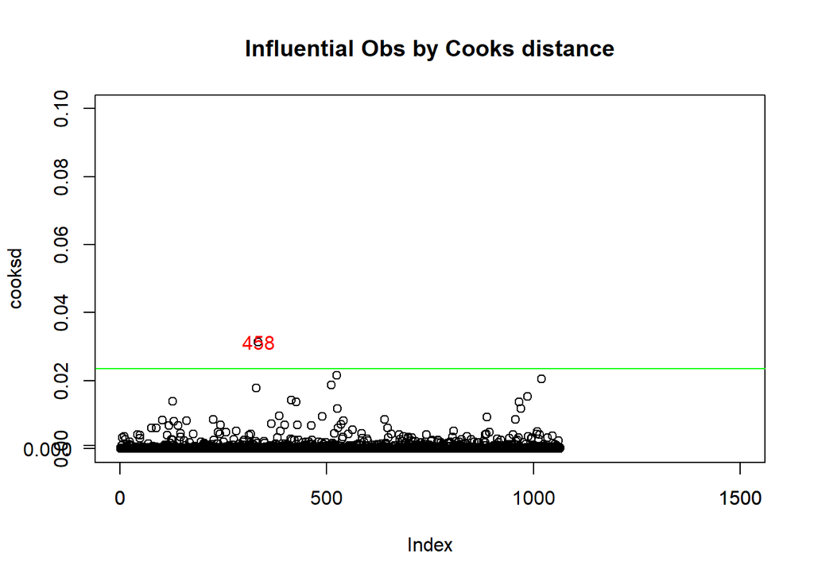

```r
par(mfrow=c(1, 1))
plot(cooksd, main="Influential Obs by Cooks distance",xlim=c(0,1500),ylim=c(0,0.1))
axis(1, at=seq(0, 1500, 1500))
axis(2, at=seq(0, 0.001, 0.001), las=1)
abline(h = 4*mean(cooksd, na.rm=T), col="green")
text(x=1:length(cooksd)+1,y=cooksd,labels=ifelse(cooksd>4*mean(cooksd,na.rm=T),names(cooksd),""), col="red")
```

#### Find the influential points in the data.

```r
influential <- as.numeric(names(cooksd)[(cooksd > 4*mean(cooksd, na.rm=T))])  # influential row numbers
head(train_data2[influential, ])
```

```
##      Id SalePrice LotArea OverallQual OverallCond TotalBsmtSF X1stFlrSF
## NA   NA        NA      NA          NA          NA          NA        NA
## NA.1 NA        NA      NA          NA          NA          NA        NA
## NA.2 NA        NA      NA          NA          NA          NA        NA
##      X2ndFlrSF GrLivArea BedroomAbvGr KitchenAbvGr GarageCars GarageArea YrSold
## NA          NA        NA           NA           NA         NA         NA     NA
## NA.1        NA        NA           NA           NA         NA         NA     NA
## NA.2        NA        NA           NA           NA         NA         NA     NA
##      YearBuiltOrRe TotalBath NBscore
## NA              NA        NA      NA
## NA.1            NA        NA      NA
## NA.2            NA        NA      NA
```

```r
influential_data=train_data2[influential, ]
```

#### Take out the influential outliers.

```r
influencial_outliers=inner_join(outliers_data,influential_data)
```

[output not shown]

```r
influencial_outliers
```

```
##  [1] Id            SalePrice     LotArea       OverallQual   OverallCond
##  [6] TotalBsmtSF   X1stFlrSF     X2ndFlrSF     GrLivArea     BedroomAbvGr
## [11] KitchenAbvGr  GarageCars    GarageArea    YrSold        YearBuiltOrRe
## [16] TotalBath     NBscore
## <0 行> (或0-长度的row.names)
```

#### Modify the Influential Outliers

Modify the data excluding the outliers and including only the influential outliers.

```r
train_data3=rbind(train_data2,influencial_outliers)
```

### STEP 4: Model with Influential Outliers

#### Modelling using the train data which includes influential_outliers

#### Model 5: with influential_outliers

```r
# Model 5: with influential_outliers
model5=lm(data=train_data3,SalePrice~OverallQual+GarageCars+YearBuiltOrRe+TotalBath+NBscore+LotArea+BedroomAbvGr+TotalBsmtSF+X1stFlrSF+X2ndFlrSF)
summary(model5)
```

```
##
## Call:
## lm(formula = SalePrice ~ OverallQual + GarageCars + YearBuiltOrRe +
##     TotalBath + NBscore + LotArea + BedroomAbvGr + TotalBsmtSF +
##     X1stFlrSF + X2ndFlrSF, data = train_data3)
##
## Residuals:
##     Min      1Q  Median      3Q     Max
## -135039  -17970   -1293   18360  101222
##
## Coefficients:
##                 Estimate Std. Error t value Pr(>|t|)
## (Intercept)   -7.887e+05  2.602e+05  -3.031 0.002644 **
## OverallQual    1.494e+04  2.392e+03   6.247 1.39e-09 ***
## GarageCars     1.445e+04  3.382e+03   4.271 2.59e-05 ***
## YearBuiltOrRe  3.426e+02  1.337e+02   2.563 0.010863 *
## TotalBath      1.374e+04  4.012e+03   3.424 0.000702 ***
## NBscore        4.500e+03  1.066e+03   4.223 3.19e-05 ***
## LotArea        4.010e+00  5.757e-01   6.965 2.00e-11 ***
## BedroomAbvGr  -1.094e+04  2.666e+03  -4.104 5.21e-05 ***
## TotalBsmtSF    1.042e+01  9.082e+00   1.147 0.252173
## X1stFlrSF      6.686e+01  9.787e+00   6.832 4.50e-11 ***
## X2ndFlrSF      4.014e+01  6.479e+00   6.195 1.87e-09 ***
## ---
## Signif. codes:  0 '***' 0.001 '**' 0.01 '*' 0.05 '.' 0.1 ' ' 1
##
## Residual standard error: 28920 on 307 degrees of freedom
## Multiple R-squared:  0.8375, Adjusted R-squared:  0.8322
## F-statistic: 158.2 on 10 and 307 DF,  p-value: < 2.2e-16
```

#### Model 6: model 5 without 2 strars or less variables

```r
model6=lm(data=train_data3,SalePrice~OverallQual+GarageCars+TotalBath+NBscore+LotArea+BedroomAbvGr+X1stFlrSF+X2ndFlrSF)
summary(model6)
```

```
##
## Call:
## lm(formula = SalePrice ~ OverallQual + GarageCars + TotalBath +
##     NBscore + LotArea + BedroomAbvGr + X1stFlrSF + X2ndFlrSF,
##     data = train_data3)
##
## Residuals:
##     Min      1Q  Median      3Q     Max
## -133210  -18199    -815   17525  103127
##
## Coefficients:
##                Estimate Std. Error t value Pr(>|t|)
## (Intercept)  -1.264e+05  1.269e+04  -9.956  < 2e-16 ***
## OverallQual   1.821e+04  2.085e+03   8.734  < 2e-16 ***
## GarageCars    1.562e+04  3.385e+03   4.614 5.80e-06 ***
## TotalBath     1.414e+04  4.043e+03   3.498 0.000538 ***
## NBscore       5.036e+03  1.056e+03   4.770 2.85e-06 ***
## LotArea       3.936e+00  5.780e-01   6.811 5.08e-11 ***
## BedroomAbvGr -1.040e+04  2.648e+03  -3.926 0.000107 ***
## X1stFlrSF     7.074e+01  7.708e+00   9.177  < 2e-16 ***
## X2ndFlrSF     3.572e+01  6.039e+00   5.915 8.79e-09 ***
## ---
## Signif. codes:  0 '***' 0.001 '**' 0.01 '*' 0.05 '.' 0.1 ' ' 1
##
## Residual standard error: 29180 on 309 degrees of freedom
## Multiple R-squared:  0.8335, Adjusted R-squared:  0.8292
## F-statistic: 193.3 on 8 and 309 DF,  p-value: < 2.2e-16
```

The relationship between above variables appear to be very strong as shown by R-Suared value and the probability. Even I try fitting the model including a few other variables which we left out, the R squared value won’t increase. As a conclude from the p-value that all variables are relevantly significant with two to three stars for the prediction of price. Hence we keep all variable in **model 5**.

**As concluded from the Adjusted R-squared value from model 5 with 0.8322, the relationship between these variables appear to be vary strong.**

## Accuracy of Model

```r
pred=model5$fitted.values


tally_table=data.frame(actual=train_data3$SalePrice, predicted=pred)

mape=mean(abs(tally_table$actual-tally_table$predicted)/tally_table$actual)
accuracy=1-mape
accuracy
```

```
## [1] 0.8895409
```

##### **We see that the accuracy of train_data3 (0.8 of the overall cleaned traindata) is 88.95%**

```r
pred_test=predict(newdata=test_data,model5)


tally_table_1=data.frame(actual=test_data$SalePrice, predicted=pred_test)

mape_test=mean(abs(tally_table_1$actual-tally_table_1$predicted)/tally_table_1$actual)
accuracy_test=1-mape_test
accuracy_test
```

```
## [1] 0.8223009
```

##### **We see that the accuracy of test_data (0.2 of the overall traindata) is 82.23%. Thus our model can predict price with an accuracy of 82.23%**